### Predicting Housing Price with Multiple Linear Regression

#### February 26, 2017

First, let us load the data and necessary packages:

```r
load("ames_train.Rdata")
library(MASS)
library(dplyr)
library(GGally)
library(data.table)
ames_train <- data.table(ames_train)
library(ggplot2)
```

#### Question 1. Make a labeled histogram (with 30 bins) of the ages of the houses in the data set, and describe the distribution.

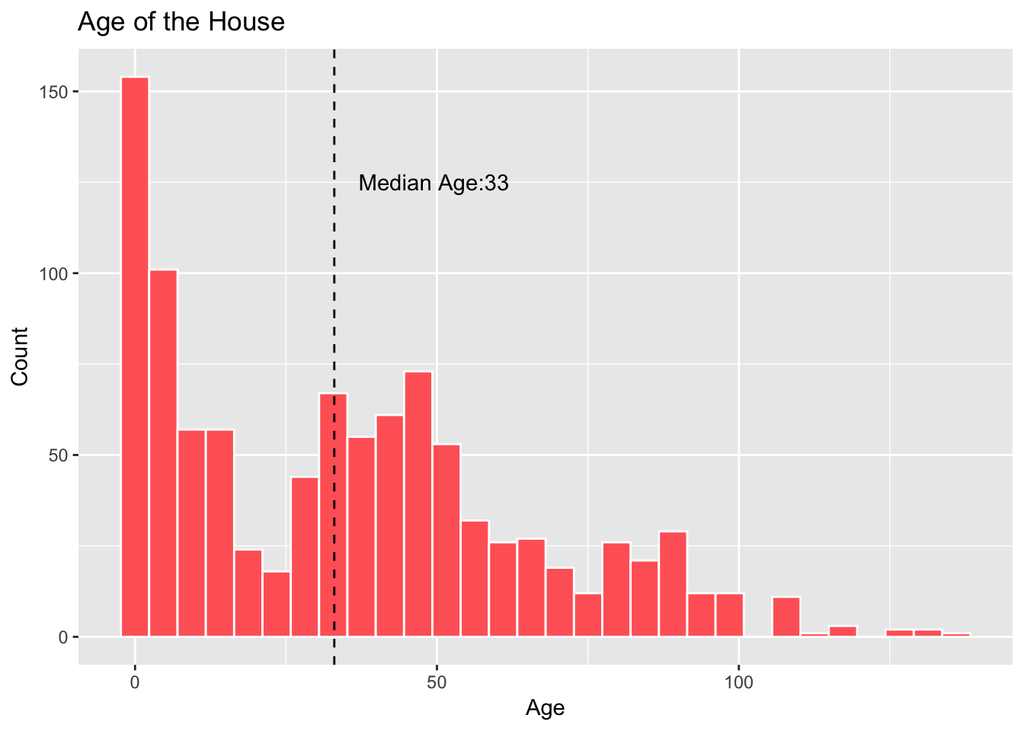

```r
ames_train$Year.Built <- as.numeric(ames_train$Year.Built)
ames_train$Yr.Sold <- as.numeric(ames_train$Yr.Sold)

ames_train$Age <- ames_train$Yr.Sold - ames_train$Year.Built

ggplot(data = ames_train, aes(x=ames_train$Age)) +
  geom_histogram(fill="#FF6666", col=I("white")) +
  geom_vline(aes(xintercept = median(ames_train$Age)), colour="black", linetype = "dashed") +
  annotate("text", x = median(ames_train$Age) * 1.5, y = 125,
                 label = paste0("Median Age:", median(ames_train$Age))) +
  labs(title = "Age of the House") +
  labs(x = "Age", y = "Count")
```

```r
summary(ames_train$Age)
```

```
##    Min. 1st Qu.  Median    Mean 3rd Qu.    Max.
##    0.00    7.00   33.00   35.56   52.00  136.00
```

For the analysis, I’ve defined the age of house to be the differece between the year of house was sold (Yr.Sold) and the year of the house was built (Year.Built). After all, our data set contains houses that were sold between 2006 and 2010.

As we can see from the histogram, the distribution is multimodal with a few data points that could potentially be outliers. In this case, the median is a more sensible measure of central tendency.

The median suggests that half of sample is aged under 33 while the other half is aged between 34 and 136! The mode also shows that over 150 houses or 15% of the houses are either brand new or less than one year old. There also seems to be a few outliers that are over 100 years old.

#### Question 2. The mantra in real estate is “Location, Location, Location!” Make a graphical display that relates a home price to its neighborhood in Ames, Iowa. Which summary statistics are most appropriate to use for determining the most expensive, least expensive, and most heterogeneous (having the most variation in housing price) neighborhoods? Report which neighborhoods these are based on the summary statistics of your choice. Report the value of your chosen summary statistics for these neighborhoods.

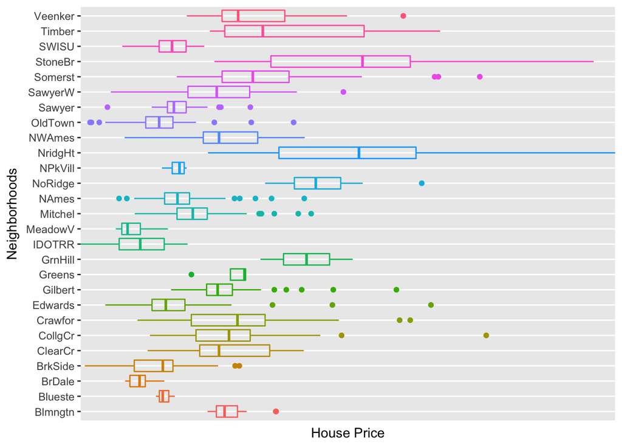

```r
ames_train$price <- as.numeric(ames_train$price)

ames_train %>% select(Neighborhood, price) %>%
  ggplot(aes(factor(Neighborhood), price)) +
  geom_boxplot(aes(color = factor(Neighborhood)),fill=NA) +
  theme(axis.text.x = element_text(angle = 90, hjust =1)) +
  scale_y_discrete(name="House Price") +
  xlab('Neighborhoods') +
  theme(legend.position='none') +
  coord_flip()
```

Three quick observations can be made here: 1) StoneBr has the higest median housing price ($340,691.5), 2) MeadowV has the lowest median housing price ($85,750) and 3) either StoneBr or NridgHt could have the most heterogeneous housing prices.

To determine the most heterogeneous neighborhood, we need to compare their standard deviation. It turns out StoneBr has the highest Std of 123,459.10 and thus it’s our most heterogeneous neighborhood.

The values of median housing and Standard Deviation for each of the three neighborhood are listed below.

```r
ames_train %>%
  group_by(Neighborhood) %>%
  filter(Neighborhood %in% c("StoneBr","MeadowV","NridgHt")) %>%
  summarize(MedianPrice = median(price),  StandardDeviation = sd(price))
```

```
## # A tibble: 3 × 3
##   Neighborhood MedianPrice StandardDeviation
##         <fctr>       <dbl>             <dbl>
## 1      MeadowV     85750.0          18939.78
## 2      NridgHt    336860.0         105088.90
## 3      StoneBr    340691.5         123459.10
```

#### Question 3. Which variable has the largest number of missing values? Explain why it makes sense that there are so many missing values for this variable.

```r
miss <- colSums(is.na(ames_train))

head(sort(miss,decreasing=TRUE), n = 1)
```

```
## Pool.QC
##     997
```

On the surface, Pool.QC seems like a variable with the largest number of NA or missing values. However, a quick look at the code book and we would learn that NA simply means the house has no backyard pool. So, our sample would tell us that the majority of houses in Ames, Iowa don’t have backyard pool. Does our sample statistics make sense in the real-world context? Let’s do a quick research and find out!

According to Realtor.com, top 10 medium-to-large cities with the highest percentage of backyard pools are all in the states that have warm weather throughout the entire year, such as Texas, California, Arizon and Florida. [Click here for link](http://www.realtor.com/news/trends/top-10-cities-for-pool-loving-homeowners/)

[figure not shown]

In contrast, the annual high temerate in Ames is only 59 degree in Fahrenheit (°F) with average snallfall of 31 inches every year. [Click here for link](http://www.usclimatedata.com/climate/ames/iowa/united-states/usia0026). Given these background information, we can safely conclude that our sample statistics are not far off from reality.

#### Question 4. We want to predict the natural log of the home prices. Candidate explanatory variables are lot size in square feet (Lot.Area), slope of property (Land.Slope), original construction date (Year.Built), remodel date (Year.Remod.Add), and the number of bedrooms above grade (Bedroom.AbvGr). Pick a model selection or model averaging method covered in the Specialization, and describe how this method works. Then, use this method to find the best multiple regression model for predicting the natural log of the home prices.

```r
Data1 <- select(ames_train, Lot.Area, Land.Slope, Year.Built, Year.Remod.Add, Bedroom.AbvGr, price)

mod1 <- lm(log(price) ~., data=Data1, na.action=na.exclude)
summary(mod1)
```

```
##
## Call:
## lm(formula = log(price) ~ ., data = Data1, na.action = na.exclude)
##
## Residuals:
##     Min      1Q  Median      3Q     Max
## -2.0878 -0.1651 -0.0211  0.1657  0.9945
##
## Coefficients:
##                  Estimate Std. Error t value Pr(>|t|)
## (Intercept)    -1.371e+01  8.574e-01 -15.996  < 2e-16 ***
## Lot.Area        1.028e-05  1.106e-06   9.296  < 2e-16 ***
## Land.SlopeMod   1.384e-01  4.991e-02   2.773  0.00565 **
## Land.SlopeSev  -4.567e-01  1.514e-01  -3.016  0.00263 **
## Year.Built      6.049e-03  3.788e-04  15.968  < 2e-16 ***
## Year.Remod.Add  6.778e-03  5.468e-04  12.395  < 2e-16 ***
## Bedroom.AbvGr   8.686e-02  1.077e-02   8.063 2.12e-15 ***
## ---
## Signif. codes:  0 '***' 0.001 '**' 0.01 '*' 0.05 '.' 0.1 ' ' 1
##
## Residual standard error: 0.279 on 993 degrees of freedom
## Multiple R-squared:  0.5625, Adjusted R-squared:  0.5598
## F-statistic: 212.8 on 6 and 993 DF,  p-value: < 2.2e-16
```

Much to my surprise, all five of the given predictors are deemed to be significant in our initial model. Thus, I will use the entire set of predictors in the model for the on-going analysis.

#### Question 5. Which home has the largest squared residual in the previous analysis (Question 4)? Looking at all the variables in the data set, can you explain why this home stands out from the rest (what factors contribute to the high squared residual and why are those factors relevant)?

```r
Data1$resid <- residuals(mod1)
Data1$SqResid <- Data1$resid^2
which.max(Data1$SqResid)
```

```
## [1] 428
```

```r
Data1[which.max(Data1$SqResid),]
```

```
##    Lot.Area Land.Slope Year.Built Year.Remod.Add Bedroom.AbvGr price
## 1:     9656        Gtl       1923           1970             2 12789
##        resid SqResid
## 1: -2.087853 4.35913
```

```r
summary(Data1)
```

```
##     Lot.Area      Land.Slope   Year.Built   Year.Remod.Add Bedroom.AbvGr
##  Min.   :  1470   Gtl:962    Min.   :1872   Min.   :1950   Min.   :0.000
##  1st Qu.:  7314   Mod: 33    1st Qu.:1955   1st Qu.:1966   1st Qu.:2.000
##  Median :  9317   Sev:  5    Median :1975   Median :1992   Median :3.000
##  Mean   : 10352              Mean   :1972   Mean   :1984   Mean   :2.806
##  3rd Qu.: 11650              3rd Qu.:2001   3rd Qu.:2004   3rd Qu.:3.000
##  Max.   :215245              Max.   :2010   Max.   :2010   Max.   :6.000
##      price            resid            SqResid
##  Min.   : 12789   Min.   :-2.0879   Min.   :0.00000
##  1st Qu.:129762   1st Qu.:-0.1651   1st Qu.:0.00601
##  Median :159467   Median :-0.0211   Median :0.02745
##  Mean   :181190   Mean   : 0.0000   Mean   :0.07732
##  3rd Qu.:213000   3rd Qu.: 0.1657   3rd Qu.:0.08078
##  Max.   :615000   Max.   : 0.9945   Max.   :4.35913
```

So far, we know that observation No.428 has the largest squared residual and has the lowest housing price of $12,789. In our sample of 1,000 houses, the median housing price is $159,467 and even the lower 25% (or the 1st quartile) can fetch a price of $129,762.

#### Question 6. Use the same model selection method you chose in Question 4 to again find the best multiple regression model to predict the natural log of home prices, but this time **replacing Lot.Area with log(Lot.Area)**. Do you arrive at a model including the same set of predictors?

```r
Data2 <- select(ames_train, Lot.Area, Land.Slope, Year.Built, Year.Remod.Add, Bedroom.AbvGr, price)

mod2 <- lm(log(price) ~ log(Lot.Area) + Land.Slope + Year.Built + Year.Remod.Add + Bedroom.AbvGr, data=Data2, na.action=na.exclude)
summary(mod2)
```

```
##
## Call:
## lm(formula = log(price) ~ log(Lot.Area) + Land.Slope + Year.Built +
##     Year.Remod.Add + Bedroom.AbvGr, data = Data2, na.action = na.exclude)
##
## Residuals:
##      Min       1Q   Median       3Q      Max
## -2.14050 -0.15650 -0.01561  0.15350  0.90854
##
## Coefficients:
##                  Estimate Std. Error t value Pr(>|t|)
## (Intercept)    -1.553e+01  8.197e-01 -18.947  < 2e-16 ***
## log(Lot.Area)   2.442e-01  1.708e-02  14.297  < 2e-16 ***
## Land.SlopeMod   1.151e-01  4.734e-02   2.431   0.0152 *
## Land.SlopeSev  -6.554e-02  1.222e-01  -0.536   0.5917
## Year.Built      5.981e-03  3.597e-04  16.628  < 2e-16 ***
## Year.Remod.Add  6.734e-03  5.190e-04  12.975  < 2e-16 ***
## Bedroom.AbvGr   5.909e-02  1.055e-02   5.599  2.8e-08 ***
## ---
## Signif. codes:  0 '***' 0.001 '**' 0.01 '*' 0.05 '.' 0.1 ' ' 1
##
## Residual standard error: 0.2649 on 993 degrees of freedom
## Multiple R-squared:  0.6056, Adjusted R-squared:  0.6032
## F-statistic: 254.1 on 6 and 993 DF,  p-value: < 2.2e-16
```

#### Question 7. Do you think it is better to log transform Lot.Area, in terms of assumptions for linear regression? Make graphs of the predicted values of log home price versus the true values of log home price for the regression models selected for Lot.Area and log(Lot.Area). Referencing these two plots, provide a written support that includes a quantitative justification for your answer in the first part of question 7.

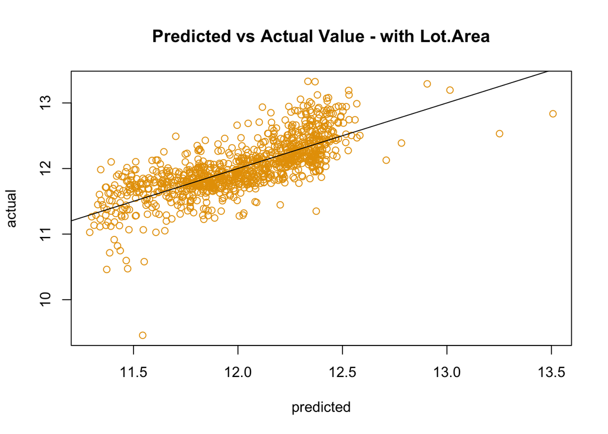

```r
plot(predict(mod1),log(Data1$price), col="#E69F00", main="Predicted vs Actual Value - with Lot.Area",
     xlab="predicted",ylab="actual")
abline(a=0,b=1)
```

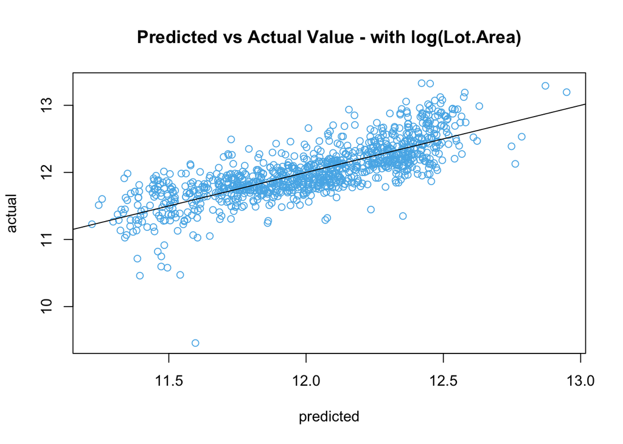

```r
plot(predict(mod2),log(Data2$price), col="#56B4E9", main="Predicted vs Actual Value - with log(Lot.Area)", xlab="predicted",ylab="actual")
abline(a=0,b=1)
```

In conclusion, I think it’s better to log transform Lot.Area because log transforming yields a stronger correlation!

The model with log(Lot.Area) looks very accurate as most data points are closely clustered around the best-fit line. We can clearly see a strong correlation between the model’s predictions and the actual observations.